# Capstone Project: Milestone Report

Johnny Kao

April 20, 2019

## Basic Information

The goal of this project is just to display that you’ve gotten used to working with the data and that you are on track to create your prediction algorithm. Please submit a report on R Pubs http://rpubs.com/ that explains your exploratory analysis and your goals for the eventual app and algorithm. This document should be concise and explain only the major features of the data you have identified and briefly summarize your plans for creating the prediction algorithm and Shiny app in a way that would be understandable to a non-data scientist manager. You should make use of tables and plots to illustrate important summaries of the data set.

The motivation for this project is to:

1. Demonstrate that you’ve downloaded the data and have successfully loaded it in.
2. Create a basic report of summary statistics about the data sets.
3. Report any interesting findings that you amassed so far.
4. Get feedback on your plans for creating a prediction algorithm and Shiny app.

## 1. Download and load the files

Download data files, unzip to working directory -

https://d396qusza40orc.cloudfront.net/dsscapstone/dataset/Coursera-SwiftKey.zip

### Load files

```r
setwd("~/Downloads/final/en_US")

# News
con <- file("en_US.news.txt", open="r")
news <- readLines(con); close(con)

# Blog
con <- file("en_US.blogs.txt", open="r")
blogs <- readLines(con); close(con)

# Twitter
con <- file("en_US.twitter.txt", open="r")
twitter <- readLines(con); close(con)
```

## 2. Statistics of datasets

We already loaded 3 files, here is the basic information:

### Blogs

```r
# Analysing lines and characters of Blogs
stri_stats_general(blogs)
```

```
##       Lines LinesNEmpty       Chars CharsNWhite
##      899288      899288   206824382   170389539
```

```
##    Min. 1st Qu.  Median    Mean 3rd Qu.    Max.
##    0.00    9.00   28.00   41.75   60.00 6726.00
```

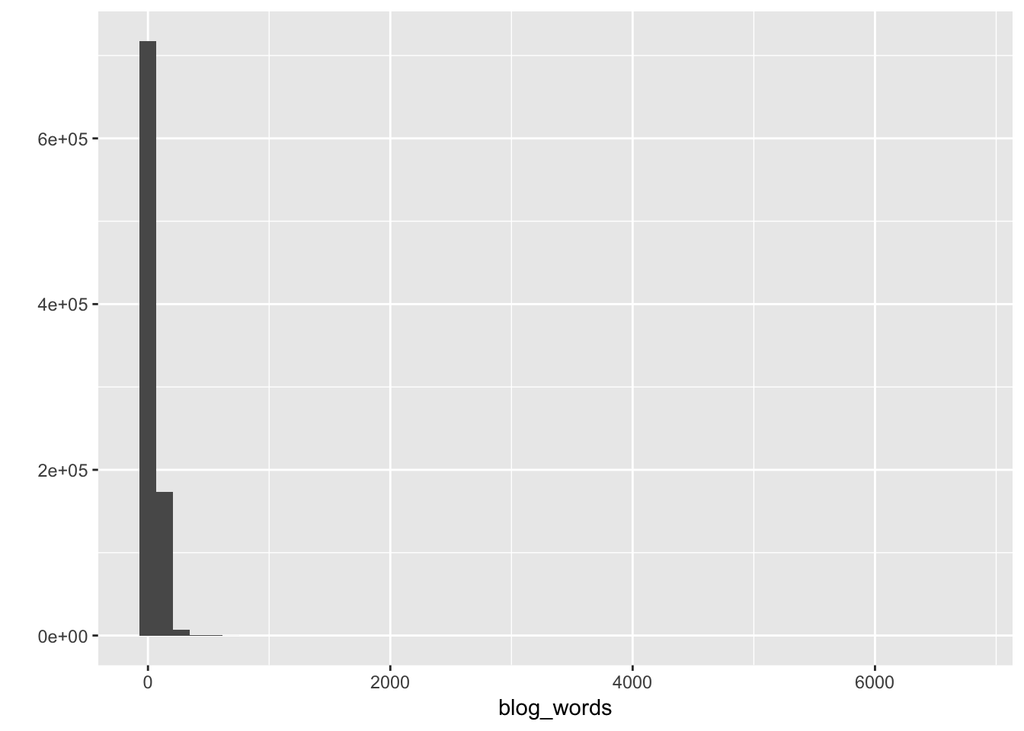

```r
blog_words <- stri_count_words(blogs); summary(blog_words); qplot(blog_words, bins = 50)
```

### Twitter

```r
# Analysing lines and characters of Blogs
stri_stats_general(twitter)
```

```
##       Lines LinesNEmpty       Chars CharsNWhite
##     2360148     2360148   162096031   134082634
```

```
##    Min. 1st Qu.  Median    Mean 3rd Qu.    Max.
##    1.00    7.00   12.00   12.75   18.00   47.00
```

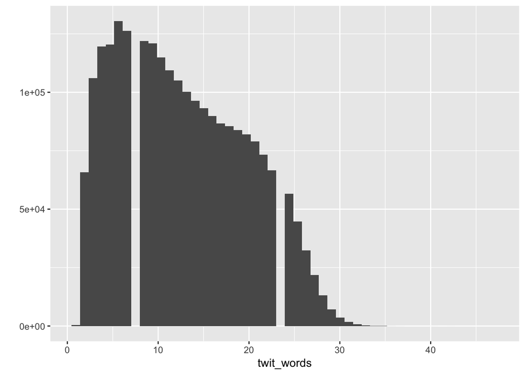

```r
twit_words <- stri_count_words(twitter); summary( twit_words); qplot(twit_words, bins = 50)
```

### News

```r
# Analysing lines and characters of Blogs
stri_stats_general(news)
```

```
##       Lines LinesNEmpty       Chars CharsNWhite
##     1010242     1010242   203223154   169860866
```

```
##    Min. 1st Qu.  Median    Mean 3rd Qu.    Max.
##    1.00   19.00   32.00   34.41   46.00 1796.00
```

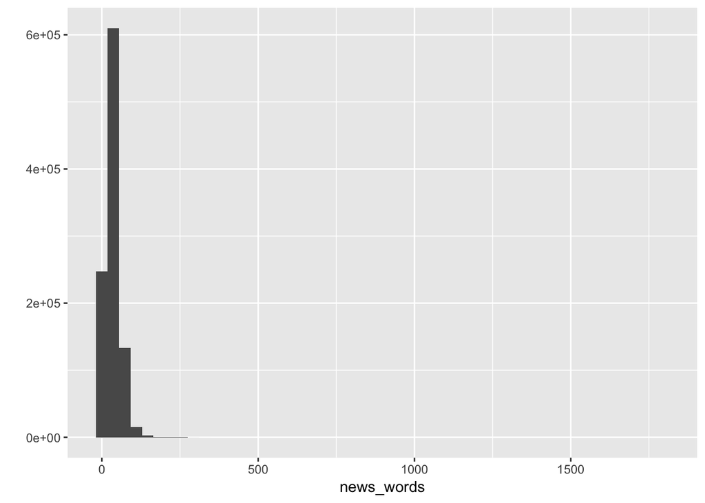

```r
news_words <- stri_count_words(news); summary(news_words); qplot(news_words, bins = 50)
```

## 3. Futher analysis of the Corpus

### Sampling the corpus for further analysis

```r
set.seed(1000)
# Sampling of blogs
sampleBlogs <- blogs[sample(1:length(blogs), 1000)]; head(sampleBlogs, 3)
```

```
## [1] "Even beyond that, though, religion permeates our culture, our language, our traditions, our public rituals, our history, and yes, our political debate. More than anything else -- more than political party, more than political history, more than any cultural icon whether it be Shakespeare, St…
## [2] "Da da da daan da, do lots."
## [3] "The first step that I’d like you to focus on before you start making any kind of decisions is What is important to you? I’m going to tell you the order of importance that I personally have in my mind. Faith, family, Business. That’s the order that I live by."
```

```r
# Sampling of twitter
sampleTwitter <- twitter[sample(1:length(twitter), 1000)]; head(sampleTwitter,3)
```

```
## [1] "I think people always believe what they want to believe, don't you? - Lillian Hellman"
## [2] "are you still on ? If so what is your store name ?"
## [3] "Glad to have back on twitter :) made my night."
```

```r
# Sampling of news
sampleNews <- news[sample(1:length(news), 1000)]; head(sampleNews, 3)
```

```
## [1] "Mr. Brennan, building on earlier remarks by lawyers for the State and Defense departments, and Attorney General Eric Holder, emphasized that drones offer the government a remarkable ability to \"distinguish more effectively between an al Qaeda terrorist and innocent civilians.\" He also said…
## [2] "\"Nothing changes. It will slow down for a couple of weeks, then it starts up again,\" said Elie Saade, one of the New Brunwick-licensed taxi drivers in municipal court Tuesday."
## [3] "The Question: OK, But who is in charge?"
```

```r
# Conslidating the sample files
sampleData <- c(sampleTwitter,sampleNews,sampleBlogs)
# Removing the original datasets from memory
rm(blogs); rm(twitter); rm(news)
```

### Cleaning the Corpus

```r
myCorpus <- Corpus(VectorSource(sampleData))
toSpace  <- content_transformer(function(x, pattern) gsub(pattern, " ", x))
myCorpus <- tm_map(myCorpus, toSpace,"\"|/|@|\\|")
myCorpus <- tm_map(myCorpus, content_transformer(tolower))
myCorpus <- tm_map(myCorpus, removeNumbers)
myCorpus <- tm_map(myCorpus, stripWhitespace)

# Remove stop words
myCorpus <- tm_map(myCorpus , removeWords, stopwords('english'))
```

### Creating ngrams

```r
library(RWeka)

myCorpusDF <-data.frame(text = unlist(sapply(myCorpus, `[`, "content")),
                        stringsAsFactors = FALSE)

findNGrams <- function(corp, grams, top) {
        ngram <- NGramTokenizer(corp, Weka_control(min = grams, max = grams,
                                                   delimiters = " \\r\\n\\t.,;:\"()?!"))
        ngram <- data.frame(table(ngram))
        ngram <- ngram[order(ngram$Freq, decreasing = TRUE),][1:top,]
        colnames(ngram) <- c("Words","Count")
        ngram
        monoGrams   <- findNGrams(myCorpusDF, 1, 100)
        biGrams     <- findNGrams(myCorpusDF, 2, 100)
        triGrams    <- findNGrams(myCorpusDF, 3, 100)
        quadriGrams <- findNGrams(myCorpusDF, 4, 100)
        }
```

### Plotting nGrams

```r
n <-20
# Plotting of the various nGrams
ggplot(monoGrams[1:n,], aes(Words, Count))   + geom_bar(stat = "identity") +
        coord_flip()
```

[figure not shown]

```r
ggplot(biGrams[1:n,], aes(Words, Count))     + geom_bar(stat = "identity") +
        coord_flip()
```

[figure not shown]

```r
ggplot(triGrams[1:n,], aes(Words, Count))    + geom_bar(stat = "identity") +
        coord_flip()
```

[figure not shown]

```r
ggplot(quadriGrams[1:n,], aes(Words, Count)) + geom_bar(stat = "identity") +
        coord_flip()
```

[figure not shown]

## What’s Next?

The next steps in the project are:

1. Continuing cleaning the corpus to to increase the accuracy of the model
2. Refining the sampling process for getting a good ngram representation without using the entire corpus
3. Building the final prediction model and testing it

For predicting the current word, the application will use mono-gram prediction data. For predicting the next word, the application will use bi-gram, tri-gram and quadri-gram prediction data.